# Predicting House Price Class in King County for Individual Use

Liu, Donghan

Donghan2

Abstract

The purpose of this project is to use four data classification techniques to predict the levels of house price in King County. I am aiming to find the best approach to get the highest accuracy so that the model would be used in predicting house price in King Country. With the usage of the most accurate model, if the required predictors’ data are provided, the outputs will be relatively the best estimated price classification. The mediums that applied are included but not limited to Boosted Tree, K-nearest Neighbors with/ without scale, and Random Forest. Consequently, the technique of Random Forest has the highest test accuracy in estimating the real classification of house price. The prediction that generated from the most accurately model is potentially beneficial for individual purchase, commercial investment, and governmental planning in the King County area.

# 1. Introduction

As the growing of real estate industries nowadays, the price of house turns out to be popular topic that people usually discuss. The contents in the conversations might straightforward to the features that affect the house price, for instance, a house with higher square feet of living would have higher list price, intuitionally. Thus, I am taking the datasets from the house price of King County where located in the central Washington State to predict classifying the house price in four classes: Lower, Lower Intermediate, Upper Intermediate, and Upper, based off the original dataset.

People are trying their best to make the better estimation in accordance with their real life experiences, but sometimes they are inappropriately precise and even incorrect because of insufficient information. Therefore, by implementing the statistical learning methods on the king county house price data, I would like to use these potential influential predictors to give a relatively best estimating. It is widely known that people are usually subject while making decisions, especially when they firmly believe their own thoughts. Whereas, unlike people’s subjective judgment, the data is objectivity. The results from the data analysis perhaps have higher accuracy than humans’ experience, it is not only because object data will give an object results, but also due to that data will more likely to have comprehensive information. Overall, I intend to find the best statistical learning model to offer constructive suggestions on the individual’s house purchasers, for instance, the buyers who have the certain value for predictors will have a roughly picture on the certain price class by utilizing the model.

# 2. Method

In the method session, I am introducing the general procedure of what I have done to finalize the best model.

```r
library(caret)
library(randomForest)
library(knitr)
library(e1071)
library(knitr)
library(kableExtra)
#Read Datasets
data = read.csv("https://daviddalpiaz.github.io/stat432sp18/projects/kc_house_data.csv")
```

## 2.1 Data Cleaning

### 2.1.1 Outliers Detection

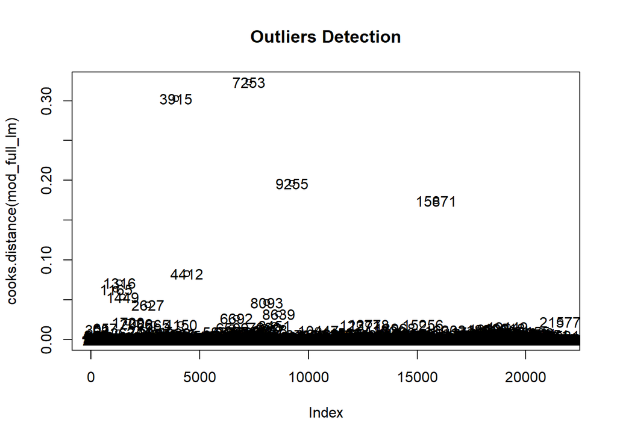

```r
#Data cleaning
house = data[complete.cases(data), ]

#Removing 'date' and 'id' variables
house = data[,-(1:2),drop=FALSE]

#Since we want the prediction to price, so fit the model with response of price variable
mod_full_lm = lm(price ~ ., data = house)

# Cook's Distance & Outliers
plot(cooks.distance(mod_full_lm), main = "Outliers Detection")
text(cooks.distance(mod_full_lm))
```

```r
house = house[-c(3915,7253,9255,15871,4412),]

#In order to reduce the magnitude, we divide price by 100000
house$price = house$price/100000
```

### 2.1.2 House Price Classification

Here, the potential outliers and variables of id and date are removed and the data is ready to process.

Classify the price by the quantile of house price. The encode are 1 = Lower; 2 = Lower Intermediate; 3 = Upper Intermediate; 4 = Upper;

```r
price = house$price
class = c()
for (i in price){
  if (i>=0.75 & i<3.215){
    class = c(class,1)
  }
  else if(i>=3.215 & i<4.5){
    class = c(class,2)
  }
  else if(i>=4.5 & i<6.45){
    class = c(class,3)
  }
  else{
    class = c(class,4)
  }
}
```

## 2.2 Model Selection

In this subsection, I am going to start the model selection by the basis of correlation and random forest feature selection.

### 2.2.1 Removal of Highly Correlated Variables

Among the model selection, the first technique is correlation. While doing the data analysis, ideally we do not want to include any predictors that are highly correlated in the final model, since it will cause the collinearity and further affect the analysis results. Also I would like my predictors are independent in order to correctly determine the interpretation of relationships.

```r
# calculate correlation matrix
correlationMatrix <- cor(house[,1:19])
highlyCorrelated <- findCorrelation(correlationMatrix, cutoff = 0.75, exact = T)
#Remove the variables that are hightly correlated
house = house[,-c(11)]
```

### 2.2.2 Random Forest Feature Selection

With the implement of random forest feature selection, by computing the importance of each variables, generate the overall percentage in order to make an intuitionistic determination for choosing the highly important predictors. Leaving them in the model for the future analysis.

```r
house$class = class
#Model selection by Random Forest
rf = randomForest(class ~ ., data = house[,-1], ntree=50, importance = TRUE)
#Importance
rf1 = varImp(rf, scale = FALSE)
rf1$Perc = rf1$Overall/sum(rf1$Overall)
rf1 = rf1[with(rf1,order(Perc,decreasing = T)),]
perc = sort(rf1$Perc, decreasing = T)
sum = c(perc[1])
for (i in 2:length(perc)){
  sum = c(sum, sum[i-1] + perc[i])
}
rf1$Sum = sum
#Print features that could be removed
kable_styling(kable(rf1[rf1$Sum>0.95,], format = "html", digits = 7), full_width = FALSE)
```

|  | Overall | Perc | Sum |
| --- | --- | --- | --- |
| bathrooms | 0.0510683 | 0.0246902 | 0.9607471 |
| view | 0.0242268 | 0.0117130 | 0.9724601 |
| floors | 0.0168286 | 0.0081362 | 0.9805962 |
| sqft_basement | 0.0160317 | 0.0077509 | 0.9883471 |
| bedrooms | 0.0127835 | 0.0061805 | 0.9945276 |
| condition | 0.0079879 | 0.0038619 | 0.9983895 |
| waterfront | 0.0017492 | 0.0008457 | 0.9992352 |
| yr_renovated | 0.0015818 | 0.0007648 | 1.0000000 |

As a 95% cut-off for sum of percentage of importance, bathrooms, view, floors, waterfront, sqft_basement, condition, bedrooms, and yr_renovated are unnecessary in this model.

### 2.2.3 Train-Test-Split

In this subsection, I removed the unimportant feature and split the new datasets to train and test data.

```r
#Train-test-split
set.seed(42)
house_red = house[,-c(1,2,3,6,7,8,9,11,13)]
house_trn_idx  = sample(nrow(house_red), size = trunc(0.80 * nrow(house_red)))
house_trn_data = house_red[house_trn_idx, ]
house_tst_data = house_red[-house_trn_idx, ]
```

## 2.3 Boosted Tree Model

The algorithm of boosted tree is aiming to strengthen the weak learners (high bias, low variance). Since the boosted tree model is good for process data with categorical features with fewer than hundreds of categories, it is suitable here.

```r
#Boosted Tree Model
mod_gbm_cv = train(house_trn_data[,1:9],as.factor(house_trn_data[,10]),
                   trControl = trainControl(method = "cv", number = 5),
                   method = "gbm",
                   verbose = FALSE)
```

## 2.4 K-nearest Neighbors

K-nearest Neighbors is a classification technique that used in recognizing the data pattern. One powerful advantage of KNN is that it is non-parametric, which does not assume the distribution of the original data, so its predictions are not limited or affected by the theoretical distribution. Plus, this approach will compute all the possible cases and give the best predicting.

### 2.4.1 KNN model without scale

The training model without scale will use the original data (non-normalized) to fit KNN model, but it might risk of bias.

```r
#Knn without scale
k = seq(1,100,5)
mod_knn = train(form = as.factor(class) ~ .,
              data = house_trn_data,
              trControl = trainControl(method = 'cv', number = 5),
              method = 'knn',
              tuneGrid = expand.grid(k = k))
```

### 2.4.2 KNN model with scale

The training model with scale will use the scaled data (normalized) to fit KNN model in order to shorten the vibration between neighbors.

```r
#Knn with scale
mod_knn_scale = train(form = as.factor(class) ~ .,
              data = house_trn_data,
              trControl = trainControl(method = 'cv', number = 5),
              method = 'knn',
              tuneGrid = expand.grid(k = k),
             preProcess = c('center','scale'))
```

## 2.5 Random Forest

Like the Boosted Tree Model, Random Forest is also the tree-based model. Random Forest is the ensemble method that merge the idea of decision tree, it generates mass of decision tree to construct a “forest” by a bootstrapped training sample. By implementing this algorithm, the final decision was made by the overall performance and the “bagging” help the learning model to get a stable and accurate prediction.

```r
#Random Forest
mod_rf = train(form = as.factor(class) ~ .,
              data = house_trn_data,
              trControl = trainControl(method = 'cv', number = 5),
              method = 'rf',
              tuneGrid = expand.grid(mtry = c(1, 2, 3, 4, 5)))
```

# 3. Results

## 3.1 Plots

Among the accuracy plot, Boosted Tree model’s accuracy is discussed in three max tree depth, which are 1, 2, 3 (highest accuracy).

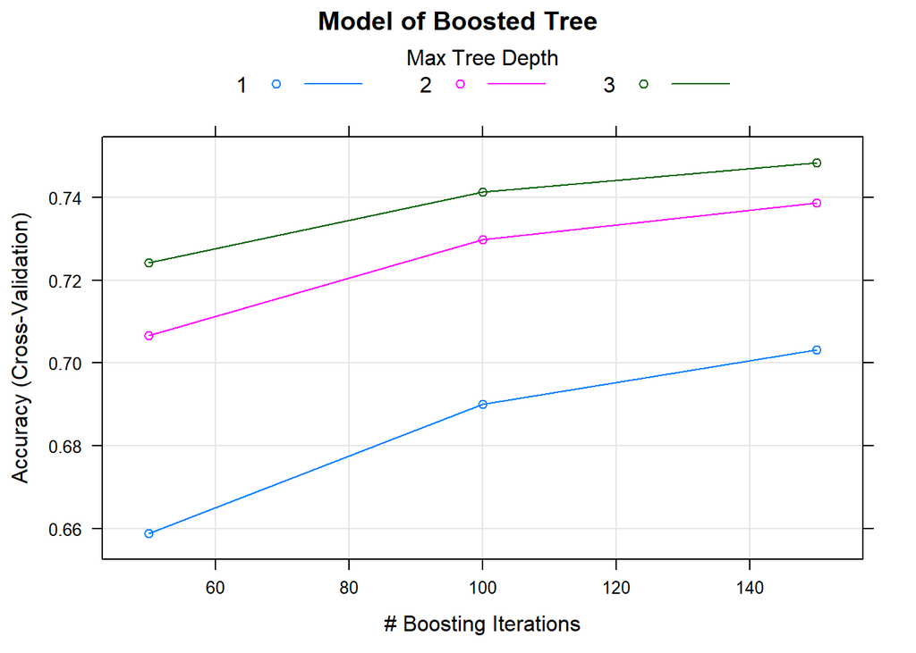

The model of KNN without scale has relatively consistent accuracy from 30-100, the maximum accuracy point appear around 50.

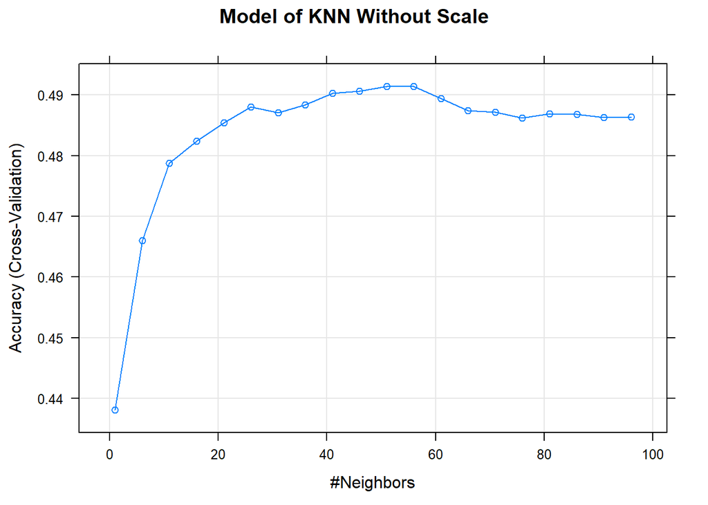

After scaling, the accuracy has an obvious increasing, but the trend of accuracy start declining from point 20.

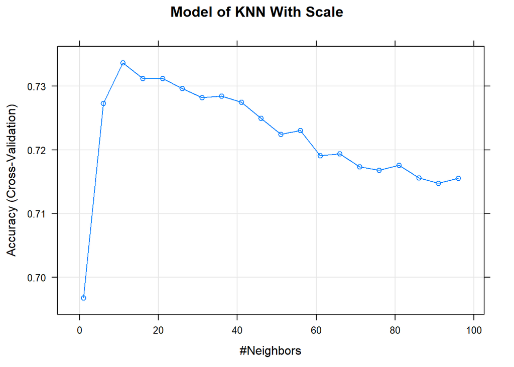

The Random Forest model is producing higher accuracy with compared to other three models.

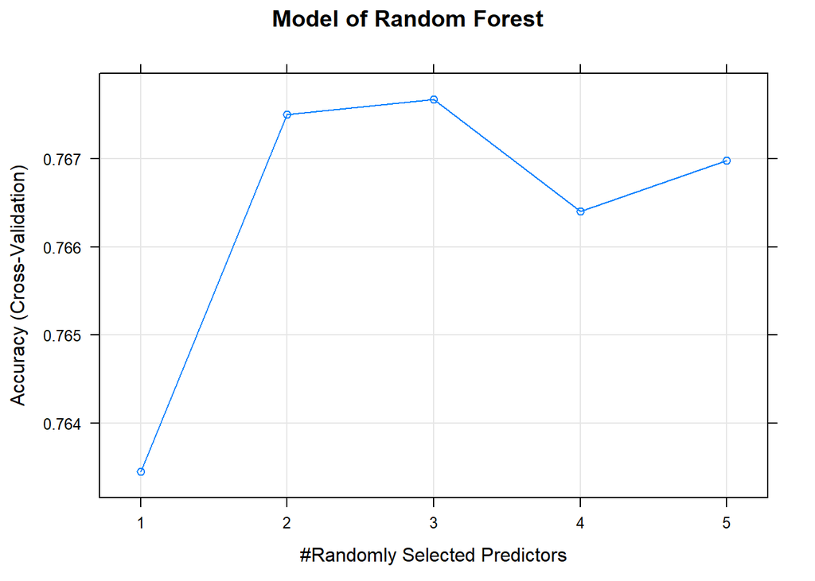

## 3.2 Accuracy

Accuracy for the four models are listed below. The random forest model is the best model regarding the measurement of Accuracy

|  | Accuracy |
| --- | --- |
| Boosted Tree | 0.7462 |
| KNN | 0.5049 |
| KNN_Scaled | 0.7397 |
| Random Forest | 0.7672 |

## 3.3 Sensitivity

|  | Boosted Tree Sensi | KNN Sensi | KNN_Scaled Sensi | Random Forest Sensi |
| --- | --- | --- | --- | --- |
| Lower | 0.8026 | 0.6342 | 0.8185 | 0.8138 |
| Lower Intermediate | 0.6837 | 0.2808 | 0.6394 | 0.7005 |
| Upper Intermediate | 0.6940 | 0.3952 | 0.6833 | 0.7101 |
| Upper | 0.8013 | 0.6947 | 0.8120 | 0.8406 |

## 3.4 Specificity

|  | Boosted Tree Spec | KNN Spec | KNN_Scaled Spec | Random Forest Spec |
| --- | --- | --- | --- | --- |
| Lower | 0.9514 | 0.8285 | 0.9413 | 0.9542 |
| Lower Intermediate | 0.8757 | 0.8524 | 0.8863 | 0.8881 |
| Upper Intermediate | 0.8779 | 0.8047 | 0.8750 | 0.8919 |
| Upper | 0.9573 | 0.8537 | 0.9507 | 0.9560 |

# 4. Discussion

“All models are wrong” –George Box. There is not best model ever, and there is not best model future, the only existing model is a better model. The predictions from these four classification techniques are not sufficiently remarkable, but it indeed provides a basic comparison between them with respect to analyzing the house price in King County.

In the data cleaning section, I was fitting the linear model with assumption of the linearity of data to remove the potential outliers, however, the data is partially nonlinear and this assumption is not valid. Reasonably, only few points have extremely high cook’s distance value and these points are removable.

While detecting the several potential issue with the models, the results that interpret the data are also significant. As mentioned before, I am trying to construct a best model to predict house price class for individuals’ usage, the best model was found is random forest. Therefore, by way of example, if a person want to purchase house in the King County, but he does not have idea that how much money he should prepare for, then, this model of random forest is useful in this case. The person need to provide the feature data of the house that he desired, such as, Square feet of home (sqft_living), square feet of lot (sqft_lot), grade, and location (zip code (zipcode), latitude (lat), longitude (long)), living room area in 2015 (sqft_living15), and lot size in 2015 (sqft_lot15), the best model in this project will have approximately 76% opportunities to predict the correct house price class, which is the amount of money that the person should use for purchasing the house. In general, constructing this best model is aiming to prepare house buyers for pre-planning.

# 5. Appendix

“Any Models are Wrong”: referenced from https://en.wikipedia.org/wiki/All_models_are_wrong

```r
str(data)
```

```
## 'data.frame':    21613 obs. of  21 variables:
##  $ id           : num  7.13e+09 6.41e+09 5.63e+09 2.49e+09 1.95e+09 ...
##  $ date         : Factor w/ 372 levels "20140502T000000",..: 165 221 291 221 284 11 57 252 340 306 ...
##  $ price        : num  221900 538000 180000 604000 510000 ...
##  $ bedrooms     : int  3 3 2 4 3 4 3 3 3 3 ...
##  $ bathrooms    : num  1 2.25 1 3 2 4.5 2.25 1.5 1 2.5 ...
##  $ sqft_living  : int  1180 2570 770 1960 1680 5420 1715 1060 1780 1890 ...
##  $ sqft_lot     : int  5650 7242 10000 5000 8080 101930 6819 9711 7470 6560 ...
##  $ floors       : num  1 2 1 1 1 1 2 1 1 2 ...
##  $ waterfront   : int  0 0 0 0 0 0 0 0 0 0 ...
##  $ view         : int  0 0 0 0 0 0 0 0 0 0 ...
##  $ condition    : int  3 3 3 5 3 3 3 3 3 3 ...
##  $ grade        : int  7 7 6 7 8 11 7 7 7 7 ...
##  $ sqft_above   : int  1180 2170 770 1050 1680 3890 1715 1060 1050 1890 ...
##  $ sqft_basement: int  0 400 0 910 0 1530 0 0 730 0 ...
##  $ yr_built     : int  1955 1951 1933 1965 1987 2001 1995 1963 1960 2003 ...
##  $ yr_renovated : int  0 1991 0 0 0 0 0 0 0 0 ...
##  $ zipcode      : int  98178 98125 98028 98136 98074 98053 98003 98198 98146 98038 ...
##  $ lat          : num  47.5 47.7 47.7 47.5 47.6 ...
##  $ long         : num  -122 -122 -122 -122 -122 ...
##  $ sqft_living15: int  1340 1690 2720 1360 1800 4760 2238 1650 1780 2390 ...
##  $ sqft_lot15   : int  5650 7639 8062 5000 7503 101930 6819 9711 8113 7570 ...
```

id: a notation for a house

date: Date house was sold

price: Price is prediction target

bedrooms: Number of Bedrooms/House

bathrooms: Number of bathrooms/bedrooms

sqft_living: square footage of the home

sqft_lot: square footage of the lot

floors: Total floors (levels) in house

waterfront: House which has a view to a waterfront

view: Has been viewed

condition: How good the condition is ( Overall )

grade: overall grade given to the housing unit, based on King County grading system

sqft_above: square footage of house apart from basement

sqft_basement: square footage of the basement

yr_built: Built Year

yr_renovated: Year when house was renovated

zipcode: zip

lat: Latitude coordinate

long: Longitude coordinate

sqft_living15: Living room area in 2015(implies– some renovations) This might or might not have affected the lotsize area

sqft_lot15: lotSize area in 2015(implies– some renovations)